# Insect Biomass & Red-Listed Species

## Data Exploration - Arlette

My Question: How does the number of red-listed species compare across landscape & plot type?

```r
#load cleaned data as own variable (to not alter others' work)
insects_ah <- read.csv("data/insects_main.csv")
```

```r
#check data structure
insects_ah %>%
  glimpse()
```

```
## Rows: 1,432
## Columns: 37
## $ plotid                     <chr> "5636_4_A", "5636_4_A", "5636_4_A", "5636_4…
## $ quadrant_id                <chr> "5636_4", "5636_4", "5636_4", "5636_4", "56…
## $ landscape_type             <chr> "Agricultural", "Agricultural", "Agricultur…
## $ landscape_type_2           <chr> "b", "b", "b", "b", "b", "b", "b", "b", "b"…
## $ plot_type                  <chr> "arable field", "arable field", "arable fie…
## $ plot_type_2                <chr> "c", "c", "c", "c", "c", "c", "c", "c", "a"…
## $ landscape_plot             <chr> "b_c", "b_c", "b_c", "b_c", "b_c", "b_c", "…
## $ bin_richness               <int> NA, NA, 311, NA, 291, NA, 474, NA, NA, NA, …
## $ rl_richness                <int> NA, NA, 5, NA, 8, NA, 13, NA, NA, NA, 5, NA…
## $ bin_coleoptera             <int> NA, NA, 24, NA, 19, NA, 33, NA, NA, NA, 32,…
## $ bin_diptera                <int> NA, NA, 209, NA, 150, NA, 231, NA, NA, NA, …
## $ bin_hemiptera              <int> NA, NA, 5, NA, 4, NA, 16, NA, NA, NA, 7, NA…
## $ bin_hymenoptera            <int> NA, NA, 54, NA, 64, NA, 117, NA, NA, NA, 90…
```

[output cut: 24 more lines]

landscape_type & plot_type:

```r
#Variable Definitions:
# RL_Richness = No. of species on the Red List of Threatened Species for Bavaria/Germany per plot & time frame.
# Landscape_Type = Landscape category of quadrant (agricultural, semi-natural, or urban).
# Plot_Type = Habitat category of plot (arable field, forest, meadow, natural, or settlement).
# Landscape (Quadrant) > Plot

#check landscape_type vs rl_richness
insects_ah %>%
  group_by(landscape_type) %>%
  select(landscape_type, rl_richness) %>%
  na.omit() %>%
  summarize(total_rl_richness = sum(rl_richness), n = n()) %>%
  arrange(desc(total_rl_richness))
```

```
## # A tibble: 3 × 3
##   landscape_type total_rl_richness     n
##   <chr>                      <int> <int>
## 1 Semi-natural                1782   176
## 2 Urban                       1584   176
## 3 Agricultural                1528   176
```

```r
#Sampling is even across landscape types
#Semi-natural >> Urban > Agricultural (pesticides?)
```

```r
#check plot_type vs rl_richness
insects_ah %>%
  group_by(plot_type) %>%
  select(plot_type, rl_richness) %>%
  na.omit() %>%
  summarize(total_rl_richness = sum(rl_richness), n = n()) %>%
  arrange(desc(total_rl_richness))
```

```
## # A tibble: 4 × 3
##   plot_type    total_rl_richness     n
##   <chr>                    <int> <int>
## 1 forest                    1741   161
## 2 meadow                    1188   134
## 3 settlement                1102   102
## 4 arable field               863   131
```

```r
#Sampling uneven across plot types. Forests may have just been more prevalent.
#Arable fields sampling on par with meadow & greater than settlement but have far fewer red-listed species.
#Forest >>> Meadow > Settlement >> Arable Field (pesticides?)
```

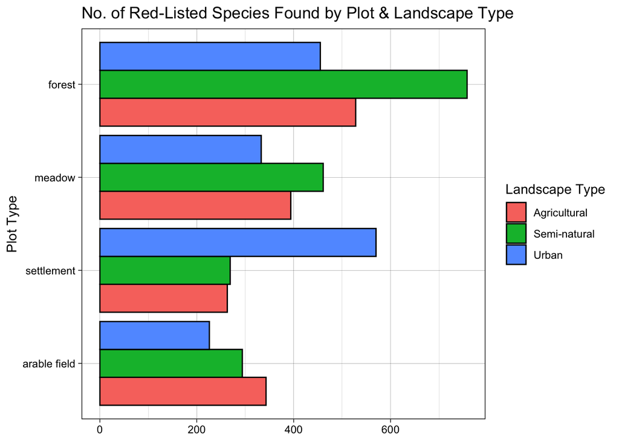

```r
#cluster column chart of landscape_type vs rl_richness by plot_type
insects_ah %>%
  group_by(landscape_type, plot_type) %>%
  select(landscape_type, plot_type, rl_richness) %>%
  na.omit() %>%
  summarize(total_rl_richness = sum(rl_richness),
            .groups='keep') %>%
  ggplot(mapping=aes(x = reorder(plot_type, total_rl_richness),
                     y = total_rl_richness,
                     fill = landscape_type))+
  geom_col(position = "dodge", color = "black", na.rm=T)+
  coord_flip()+
  labs(x = "Plot Type", y = NULL,
       title = "No. of Red-Listed Species Found by Plot & Landscape Type",
       fill = "Landscape Type")+
  theme_linedraw()
```

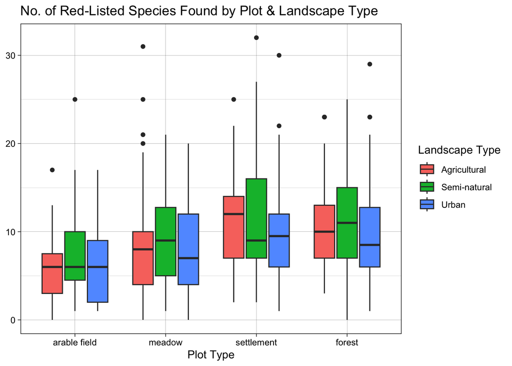

```r
#boxplot of landscape_type vs rl_richness by plot_type
insects_ah %>%
  group_by(landscape_type, plot_type) %>%
  select(landscape_type, plot_type, rl_richness) %>%
  na.omit() %>%
  ggplot(mapping=aes(x = reorder(plot_type, rl_richness),
                     y = rl_richness,
                     fill = landscape_type))+
  geom_boxplot(na.rm = T)+
  labs(x = "Plot Type", y = NULL,
       title = "No. of Red-Listed Species Found by Plot & Landscape Type",
       fill = "Landscape Type")+
  theme_linedraw()
```

Build a Map:

```r
#register
register_stadiamaps("1ad11010-4c59-42b0-a160-0dab4e61577f", write = FALSE)
```

```r
#get mins and maxes for longitude & latitude
insects_ah %>%
  select(c(lat, long, rl_richness)) %>%
  filter(lat != "NA" & long != "NA" & rl_richness != "NA") %>% #omit NAs
  summary()
```

```
##       lat             long        rl_richness
##  Min.   :46.12   Min.   :10.59   Min.   : 0.000
##  1st Qu.:46.85   1st Qu.:11.41   1st Qu.: 5.000
##  Median :47.44   Median :12.67   Median : 8.000
##  Mean   :47.46   Mean   :12.28   Mean   : 9.269
##  3rd Qu.:48.26   3rd Qu.:13.00   3rd Qu.:13.000
##  Max.   :48.76   Max.   :13.41   Max.   :32.000
```

```r
#set latitude and longitude ranges
lat <- c(46.12, 48.76)
long <- c(10.59, 13.41)
#make bbox with 3% (f=0.03) buffer
bbox <- make_bbox(long, lat, f=0.03)
```

```r
#load map
map <- get_stadiamap(bbox, maptype = "stamen_terrain", zoom = 7)
```

```
## ℹ © Stadia Maps © Stamen Design © OpenMapTiles © OpenStreetMap contributors.
```

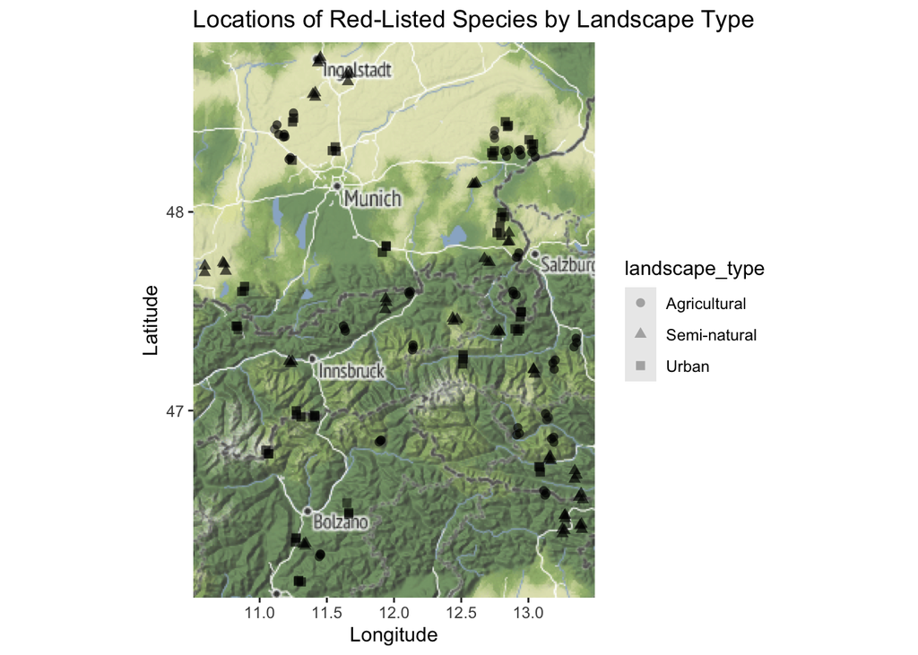

```r
#plot map by landscape type
ggmap(map)+
  geom_point(data=insects_ah %>%
               filter(rl_richness > 0),
             aes(long, lat, shape = landscape_type), color="black", size=2, alpha=0.3)+
  labs(x="Longitude", y="Latitude", title="Locations of Red-Listed Species by Landscape Type")
```

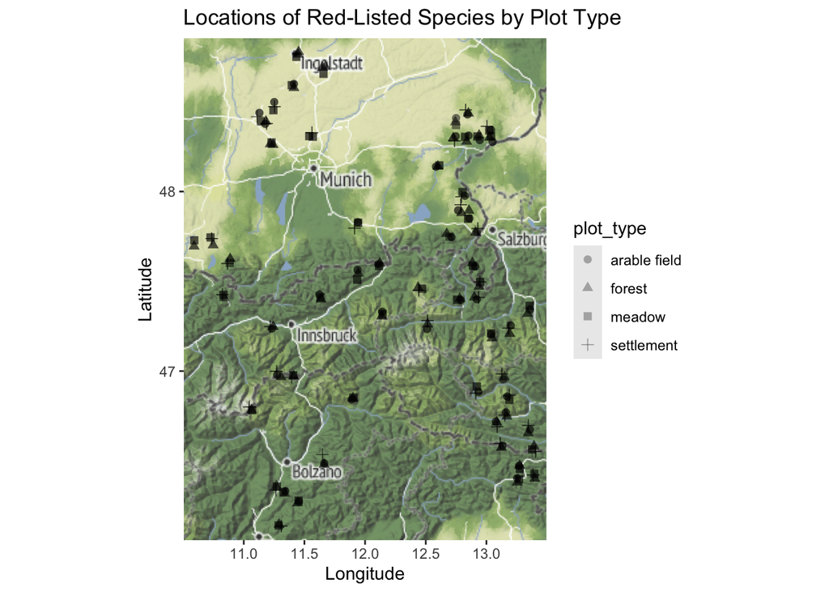

```r
#plot map by plot type
ggmap(map)+
  geom_point(data=insects_ah %>%
               filter(rl_richness > 0),
             aes(long, lat, shape = plot_type), color="black", size=2, alpha=0.3)+
  labs(x="Longitude", y="Latitude", title="Locations of Red-Listed Species by Plot Type")
```

My Conclusion: The number of red-listed species is lowest in agricultural landscapes & arable fields. Possible reasons are the use of pesticides or lack of edible plants (food grown for humans is not always edible to native insects).

## Data Exploration - Tyler

My Question: How does the biomass collected (g) compare across landscape & plot type?

```r
#load cleaned data as own variable (to not alter others' work)
insects_ts <- read_csv("data/insects_main.csv")
```

```r
#Variable Definitions:
# Biomass = Insect biomass in g.
# Landscape_Type = Landscape category of quadrant (agricultural, semi-natural, or urban).
# Plot_Type = Habitat category of plot (arable field, forest, meadow, natural, or settlement).

#Check landscape_type vs biomass
insects_ts %>%
  group_by(landscape_type) %>%
  select(landscape_type, biomass) %>%
  na.omit() %>%
  summarize(total_biomass = sum(biomass), n = n()) %>%
  arrange(desc(total_biomass))
```

```
## # A tibble: 3 × 3
##   landscape_type total_biomass     n
##   <chr>                  <dbl> <int>
## 1 Agricultural          23210.   459
## 2 Semi-natural          22321.   446
## 3 Urban                 18198.   434
```

```r
#Sampling is not even across landscape types.
```

```r
#Check plot_type vs biomass
insects_ts %>%
  group_by(plot_type) %>%
  select(plot_type, biomass) %>%
  na.omit() %>%
  summarize(total_biomass = sum(biomass), n = n()) %>%
  arrange(desc(total_biomass))
```

```
## # A tibble: 4 × 3
##   plot_type    total_biomass     n
##   <chr>                <dbl> <int>
## 1 forest              20810.   414
## 2 meadow              16020.   335
## 3 arable field        15908.   329
## 4 settlement          10992.   261
```

```r
#Sampling is not even across plot types.
```

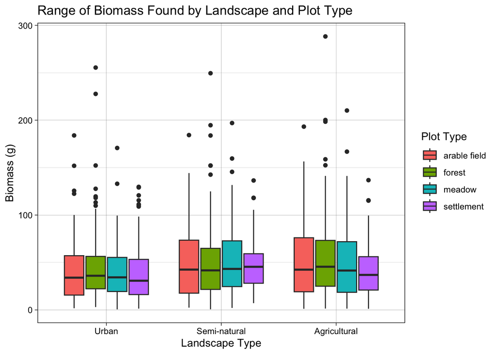

```r
#boxplot of landscape_type vs biomass by plot_type
insects_ts %>%
  group_by(landscape_type, plot_type) %>%
  select(landscape_type, plot_type, biomass) %>%
  na.omit() %>%
  ggplot(aes(x = reorder(landscape_type, biomass), y = biomass, fill = plot_type))+
  geom_boxplot()+
  labs(title = "Range of Biomass Found by Landscape and Plot Type",
       x="Landscape Type",
       y = "Biomass (g)",
       fill = "Plot Type")+
  theme_linedraw()
```

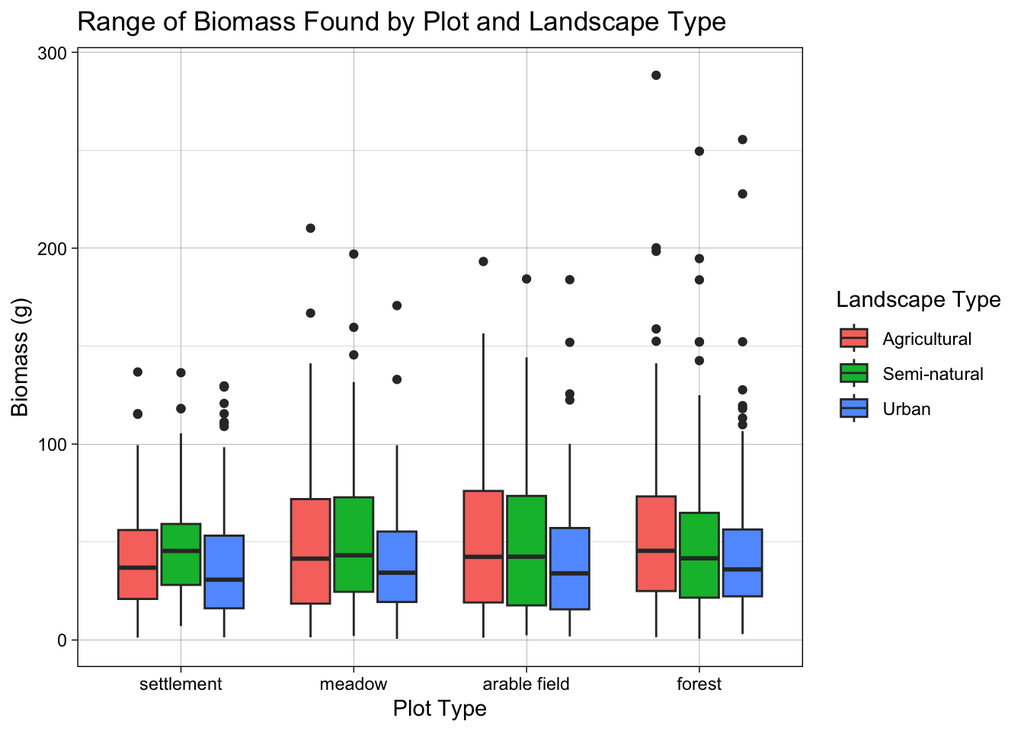

```r
#boxplot of plot_type vs biomass by landscape_type
insects_ts %>%
  group_by(landscape_type, plot_type) %>%
  select(landscape_type, plot_type, biomass) %>%
  na.omit() %>%
  ggplot(aes(x = reorder(plot_type, biomass), y = biomass, fill = landscape_type))+
  geom_boxplot()+
  labs(title = "Range of Biomass Found by Plot and Landscape Type",
       x="Plot Type",
       y = "Biomass (g)",
       fill = "Landscape Type")+
  theme_linedraw()
```

```r
#Check landscape_type vs biomass
insects_ts %>%
  group_by(plot_type, landscape_type) %>%
  select(landscape_type,plot_type, biomass) %>%
  na.omit() %>%
  summarize(total_biomass = sum(biomass), n = n(),
            .groups = 'keep') %>%
  arrange(desc(n))
```

```
## # A tibble: 12 × 4
## # Groups:   plot_type, landscape_type [12]
##    plot_type    landscape_type total_biomass     n
##    <chr>        <chr>                  <dbl> <int>
##  1 forest       Semi-natural           8280.   169
##  2 arable field Agricultural           7517.   150
##  3 settlement   Urban                  5682.   145
##  4 forest       Agricultural           7131.   129
##  5 meadow       Semi-natural           6404.   124
##  6 meadow       Agricultural           5827.   117
##  7 forest       Urban                  5399.   116
##  8 arable field Semi-natural           5062.   100
##  9 meadow       Urban                  3789.    94
## 10 arable field Urban                  3329.    79
## 11 settlement   Agricultural           2735.    63
## 12 settlement   Semi-natural           2576.    53
```

```r
#Sampling is not even across plot/landscape types. Differences in the total biomass below are likely influenced sampling differences.
```

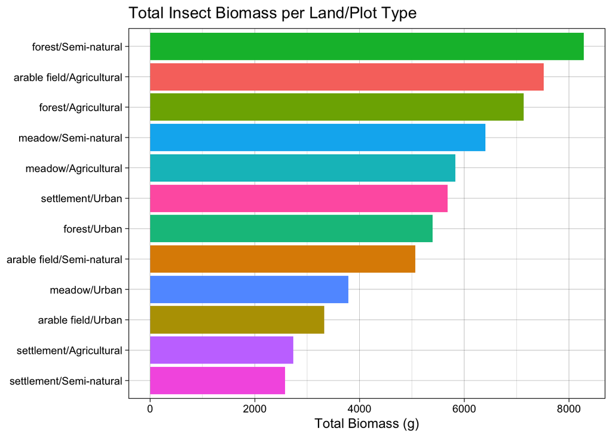

```r
#graph of the total biomass collected in every landscape/plot type combination
insects_ts %>%
  group_by(plot_type, landscape_type) %>%
  select(landscape_type, plot_type, biomass) %>%
  na.omit() %>%
  summarize(tot_biomass=sum(biomass),
            .groups = 'keep') %>%
  mutate(land_plot=paste(plot_type, landscape_type, sep = "/")) %>%
  ggplot(aes(x=tot_biomass, y=reorder(land_plot, tot_biomass), fill=land_plot))+
  geom_col()+
  labs(title="Total Insect Biomass per Land/Plot Type",
       y=NULL,
       x="Total Biomass (g)")+
  theme_linedraw()+
  theme(legend.position = "none")
```

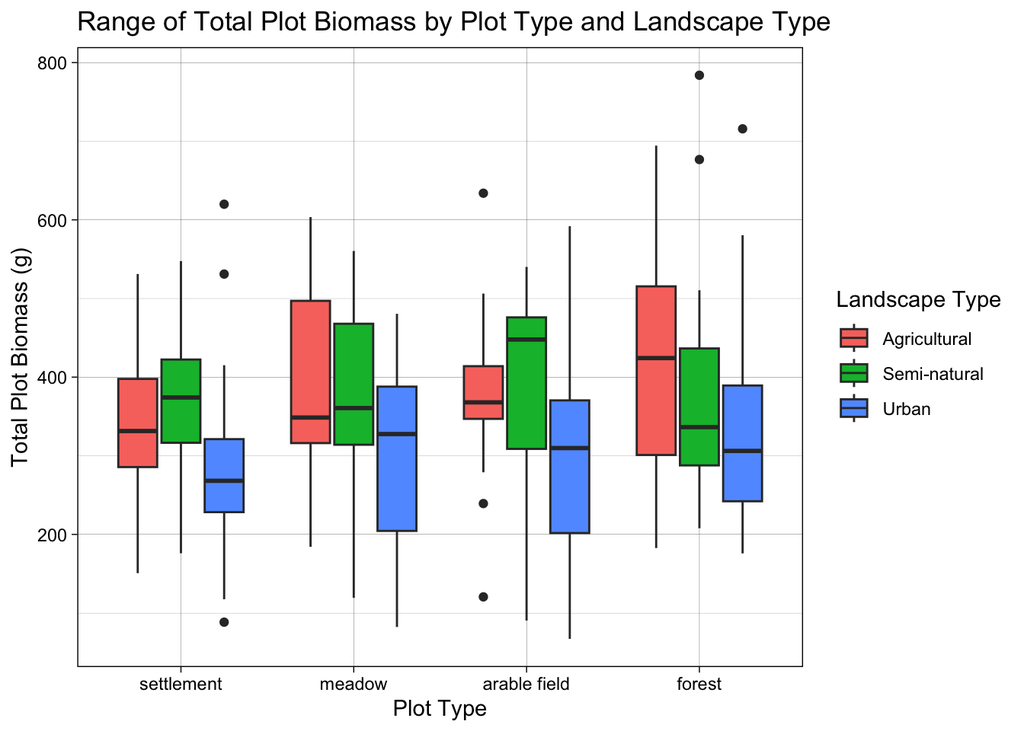

```r
#boxplot of plot_type vs biomass by landscape_type
insects_ts %>%
  filter(excluded!=1) %>%
  group_by(plotid) %>%
  summarize(biomass=sum(biomass), landscape_type=landscape_type[1], plot_type=plot_type[1]) %>%
  select(landscape_type, plot_type, biomass) %>%
  na.omit() %>%
  ggplot(aes(x = reorder(plot_type, biomass), y = biomass, fill = landscape_type))+
  geom_boxplot()+
  labs(title = "Range of Total Plot Biomass by Plot Type and Landscape Type",
       x="Plot Type",
       y = "Total Plot Biomass (g)",
       fill = "Landscape Type")+
  theme_linedraw()
```